# Fatal Crashes in Austin, Texas

Author

Robert Crump

Published

July 1, 2023

### Introduction & Background

A major interstate cuts through the middle of downtown Austin, Texas. I-35 holds a potent historical significance for the city and radiates at the center of a current debate about its future. Impacts to the local community are substantial and multi-faceted, so any attempt to measure the highway’s effect on the surrounding population implies a choice of focus. In this blog, the dimension I examine is fatal vehicle collisions. This metric focuses attention because it’s more relatable than a distributed impact like pollution or economic development. After peaking during the pandemic, traffic deaths have marginally declined. The Department of Transportation estimates that [9,330 people died](https://crashstats.nhtsa.dot.gov/Api/Public/ViewPublication/813482) as a result of vehicle collisions in the first quarter of 2023. I intend to analyze other dimensions of community impact and perform some statistical work, but first I will simply count events in a defined area.

The nature of transportation data means that I get the opportunity to refresh some GIS skills. Even after making many maps before, I gained some knowledge around troubleshooting GIS irregularities and got to practice design. It’s also important to keep in mind that transportation data is inherently behavioral information. Counting vehicle collisions is a measure of stationary incidents, but human travel happens over non-uniform spaces at different speeds and times. This idea will become more important later when build a statistical model, but for now we can just flatten the world and take a raw count. I’ve started initial research into distance-decay models and how to create one in R for myself. The deliverable for this project is the HTML widget below. I’m still learning `leaflet`, and iterating on the final design.

[interactive chart not shown]

Click here for a full screen version

### Data Description

The Texas Department of Transportation (TxDOT) hosts a repository of vehicle collision reports on its [Crash Reports Information System (CRIS)](https://www.txdot.gov/data-maps/crash-reports-records.html), however, this database is restricted to official use and requires a login to gain access. Thankfully, the City of Austin (CoA) publishes a subset of local crash records on its [open data portal](https://data.austintexas.gov/Transportation-and-Mobility/Vision-Zero-Crash-Report-Data-Crash-Level-Records/y2wy-tgr5). Each crash record contains lat-lon coordinates among many other variables like time of day and number of injuries. With just this dataset and a few lines of code from `sf` package, we can generate a map of crashes by plotting the coordinates to x-y chart axes.

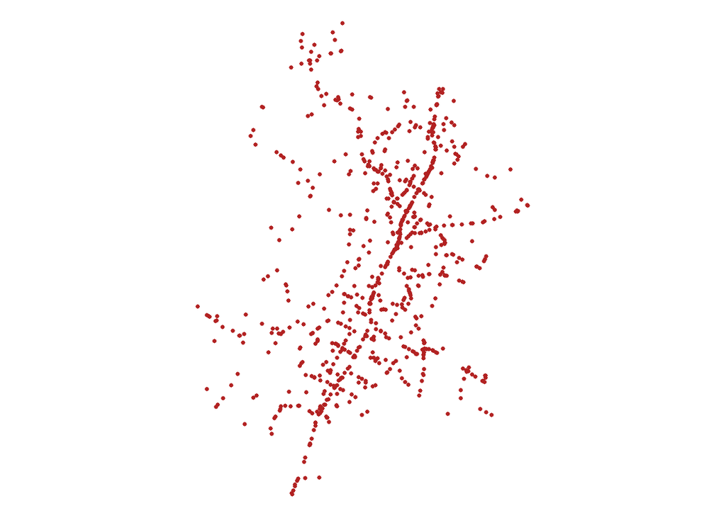

Even lacking context, we can observe a spatial relationship and concentration of crashes in a meaningful pattern. Anyone familiar with Austin’s geography would instantly recognize the source of the vertical cluster as I-35. Each crash report contains a variety of rich information, including a street name. The CoA data portal also contains [a shapefile of local roadways](https://data.austintexas.gov/dataset/Street-Centerline/8hf2-pdmb) stored as `linestrings`. Below are maps of all the local roadways and I-35 isolated.

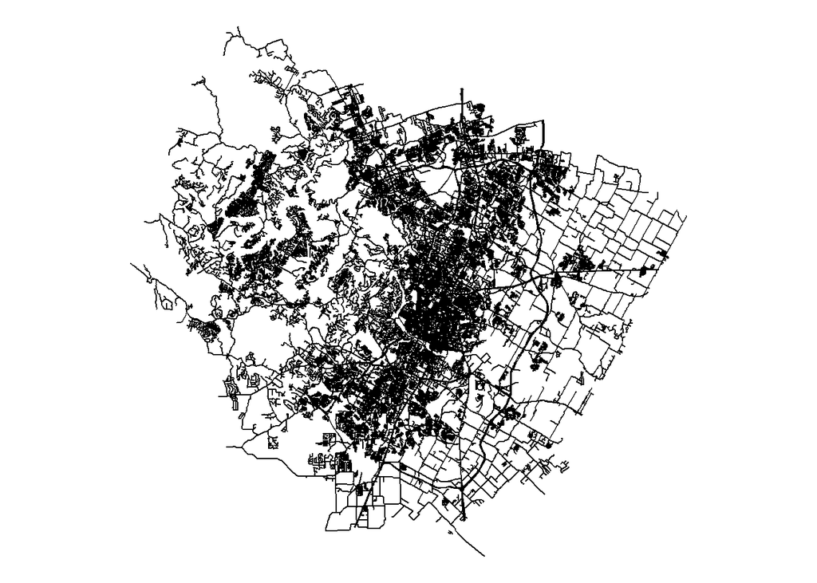

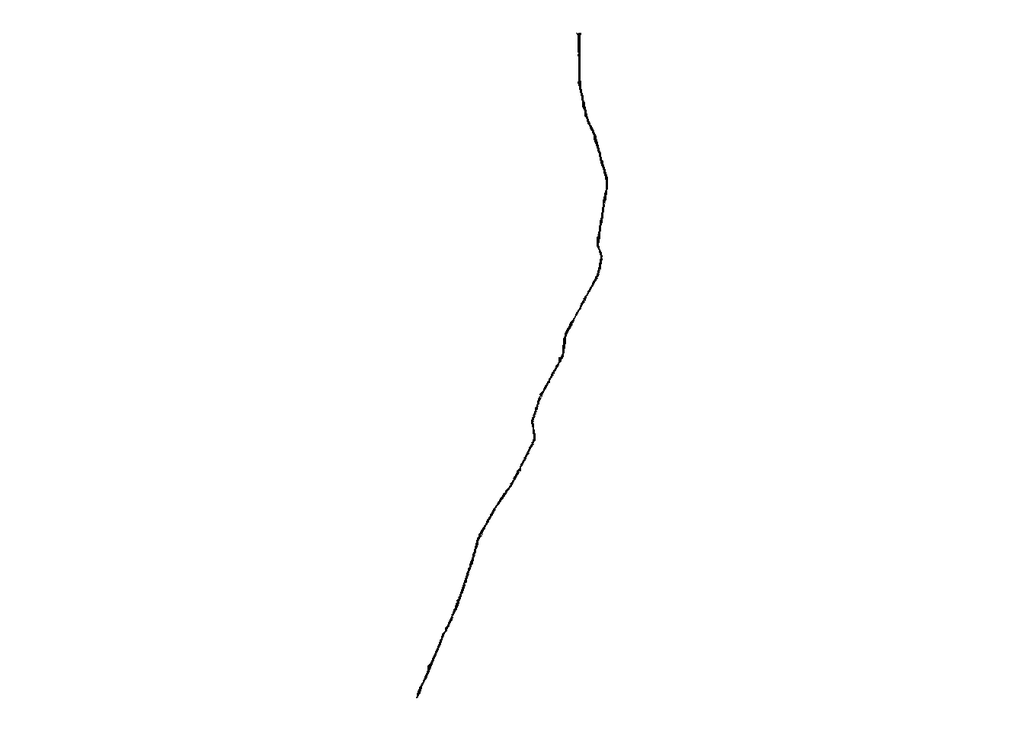

To estimate crash density around I-35, I need to orient it in space by placing it within a boundary. If I were to compare crash density in and around the highway compared to the rest of the land mass of Texas, for instance, the scale between the two areas wouldn’t allow any kind of meaningful interpretation. I decided to use Travis County as my boundary because it contains all of Austin and it’s a familiar shape to local residents. I may consider a different shape in the future because a smaller version of the disproportionate scales is reproduced within Travis County. But as a proof of concept, it works well. I decided to source this boundary from the [Travis County open data portal](https://tnr-traviscountytx.opendata.arcgis.com/datasets/TravisCountyTX::boundary/explore?location=30.324646%2C-97.770000%2C10.82) initially, then switched to sourcing it from CoA.

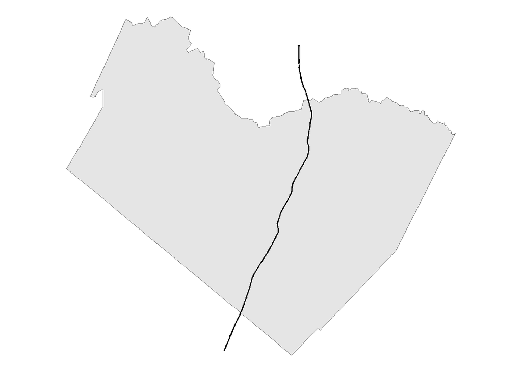

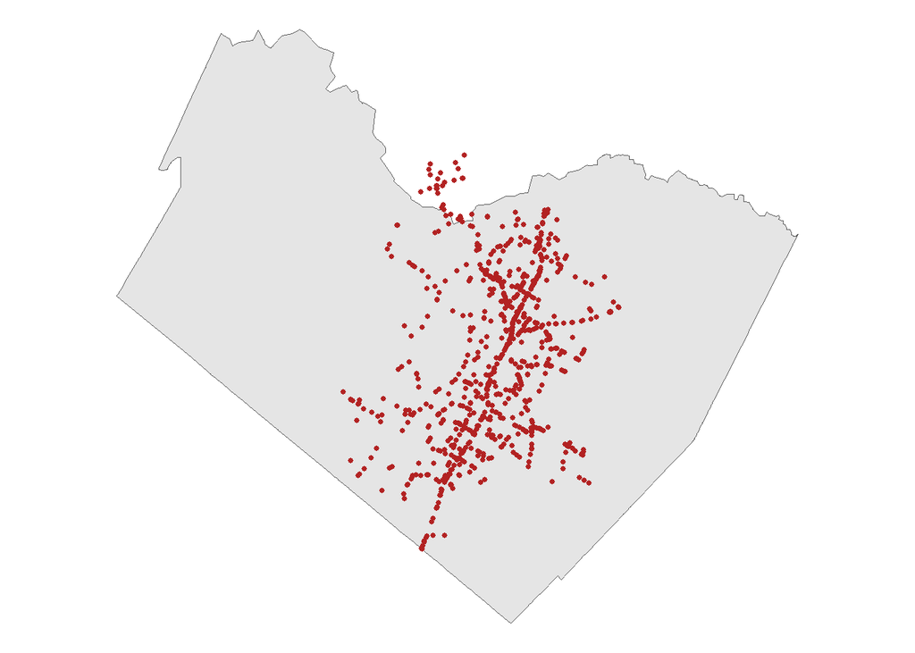